# VK-DWMR Final

2024-04-28

# Dementia Prediction

## Introduction

Dementia refers to a range of cognitive declines that hinder daily functioning, with memory loss being a common example. Rather than a single disease, it encompasses various symptoms that affect memory and thinking skills, ultimately impacting a person’s ability to carry out everyday activities. As a Cognitive Science major specializing in Neuroscience, I find it fitting to do an analysis on Dementia, since it has been fascinating the world of neuroscience to this day. In this project, I aim to identify key features associated with dementia onset and progression, ultimately constructing a robust predictive model capable of accurately classifying individuals at risk of developing dementia.

## Understanding the Data

For the data, I used two publicly available datasets on OASIS (https://sites.wustl.edu/oasisbrains/): - oasis_cross-sectional.csv: Cross-sectional MRI Data in Young, Middle Aged, Nondemented and Demented Older Adults - oasis_longitudinal.csv: Longitudinal MRI Data in Young, Middle Aged, Nondemented and Demented Older Adults

### Demographics Info

- **M.F** - Gender
- **Hand** - Handedness *(actually all subjects were right-handed so I will drop this column)*
- **Age**
- **EDUC** - Years of education
- **SES** - Socioeconomic status as assessed by the Hollingshead Index of Social Position and classified into categories from *1 (highest status)* to *5 (lowest status)*

### Clinical Info

- **MMSE** - Mini-Mental State Examination score *(range is from 0 = worst to 30 = best)*
- **CDR** - Clinical Dementia Rating *(0 = no dementia, 0.5 = very mild AD, 1 = mild AD, 2 = moderate AD)*

#### Derived anatomic volumes

- **eTIV** - Estimated total intracranial volume, mm3
- **nWBV** - Normalized whole-brain volume, expressed as a percent of all voxels in the atlas-masked image that are labeled as gray or white matter by the automated tissue segmentation process
- **ASF** - Atlas scaling factor (unitless). Computed scaling factor that transforms native-space brain and skull to the atlas target (i.e., the determinant of the transform matrix)

### Interpretations

Scores of 24 or higher out of 30 indicate normal cognition, while lower scores can suggest varying degrees of cognitive impairment: severe (≤9 points), moderate (10–18 points), or mild (19–23 points). Adjustment for education and age may be needed. Even a perfect score doesn’t exclude dementia. Low scores often indicate dementia, but other mental disorders can also affect results. Physical issues like hearing or vision problems, or motor deficits, can interfere with interpretation if not properly noted.

### Clinical Dementia Rating (CDR)

The CDR™ in one aspect is a 5-point scale used to characterize six domains of cognitive and functional performance applicable to Alzheimer disease and related dementias: Memory, Orientation, Judgment & Problem Solving, Community Affairs, Home & Hobbies, and Personal Care. This score is useful for characterizing and tracking a patient’s level of impairment/dementia: * 0 = Normal * 0.5 = Very Mild Dementia * 1 = Mild Dementia * 2 = Moderate Dementia * 3 = Severe Dementia

### Estimated total intracranial volume (eTIV)

The ICV measure, sometimes referred to as total intracranial volume (TIV), refers to the estimated volume of the cranial cavity as outlined by the supratentorial dura matter or cerebral contour when dura is not clearly detectable. ICV, along with age and gender are reported as covariates to adjust for regression analyses in investigating progressive neurodegenerative brain disorders, such as Alzheimer’s disease, aging and cognitive impairment.

I uploaded these files in the file pane on the right and read them as follows.

```r
data1 <- read.csv("oasis_longitudinal.csv")
data2 <- read.csv("oasis_cross-sectional.csv")
print(sample_n(data1, 5))
```

```
##   Subject.ID        MRI.ID       Group Visit MR.Delay M.F Hand Age EDUC SES
## 1  OAS2_0101 OAS2_0101_MR3 Nondemented     3     1631   F    R  76   18   2
## 2  OAS2_0066 OAS2_0066_MR1    Demented     1        0   M    R  61   18   1
## 3  OAS2_0161 OAS2_0161_MR1 Nondemented     1        0   M    R  77   16   1
## 4  OAS2_0073 OAS2_0073_MR2 Nondemented     2      580   F    R  72   14   3
## 5  OAS2_0028 OAS2_0028_MR2    Demented     2      610   M    R  66   18   2
##   MMSE CDR eTIV  nWBV   ASF
## 1   30   0 1379 0.757 1.273
## 2   30   1 1957 0.734 0.897
## 3   29   0 1818 0.734 0.965
## 4   28   0 1512 0.777 1.161
## 5   21   1 1562 0.717 1.124
```

```r
print(sample_n(data2, 5))
```

```
##              ID M.F Hand Age Educ SES MMSE CDR eTIV  nWBV   ASF Delay
## 1 OAS1_0425_MR1   F    R  78    1   4   23 1.0 1461 0.715 1.201   N/A
## 2 OAS1_0315_MR1   M    R  77    5   1   25 0.5 1604 0.773 1.094   N/A
## 3 OAS1_0314_MR1   M    R  27   NA  NA   NA  NA 1720 0.840 1.020   N/A
## 4 OAS1_0395_MR1   F    R  26   NA  NA   NA  NA 1295 0.834 1.356   N/A
## 5 OAS1_0332_MR1   M    R  72    1   3   29 0.0 1734 0.762 1.012   N/A
```

## Data Manipulation

In this section of code I wanted to clean the data by removing unnecessary columns (Hand and Delay), handle missing values, and create a new column Dementia based on the CDR variable.

## Exploratory Data Analysis

In this section I wanted to include violin plots and jitter plots to visualize the distribution and relationships between variables such as age, gender, education level, socioeconomic status, MMSE score, whole-brain volume, and dementia diagnosis (CDR). The analysis aims to identify any potential associations or patterns that may help in understanding dementia indicators

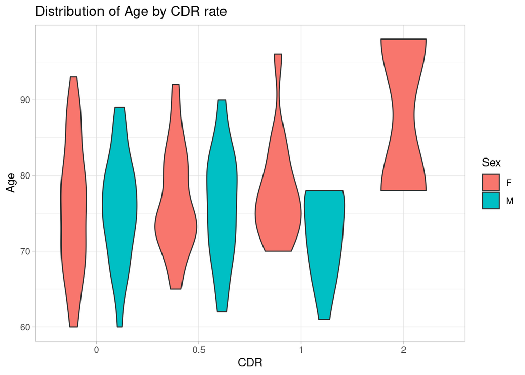

From this violin plot, there seems to be no obvious connection between Age/Sex and Dementia Diagnosis. Moving on…

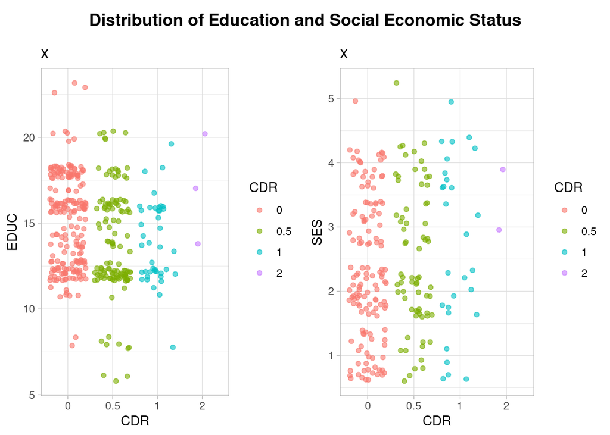

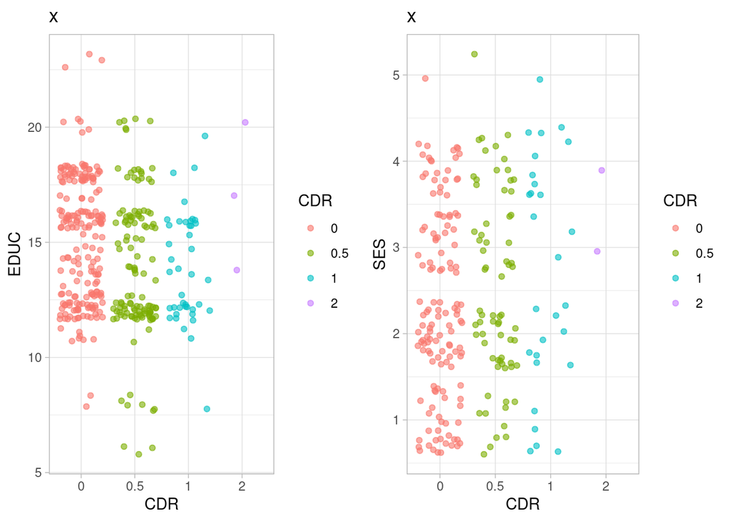

From this jitter plot, there still seems to be no obvious connection between Education Level/Social Economic Status and Dementia Diagnosis. Sigh… we move on.

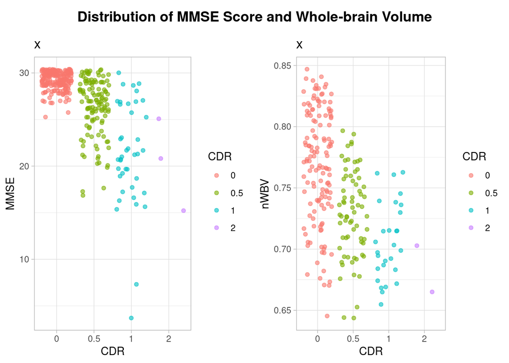

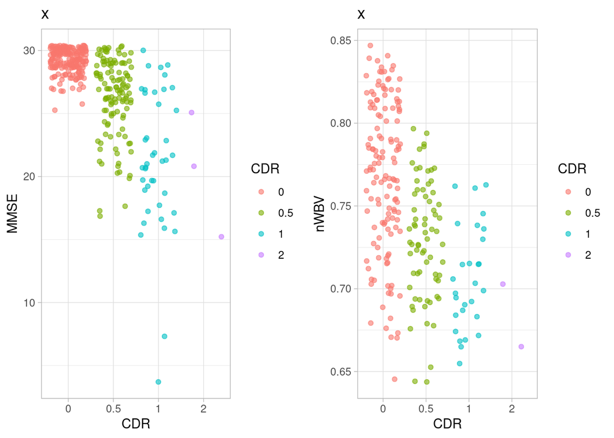

While the MMS examination results of subjects not diagnosed with Dementia concentrate near 27-30 point rate, MMSE results of subjects diagnosed with Dementia seems to be more spread out. We can see that subjects had the highest MMSE score but still have Clinical Dementia Rating of 0.5 or 1.

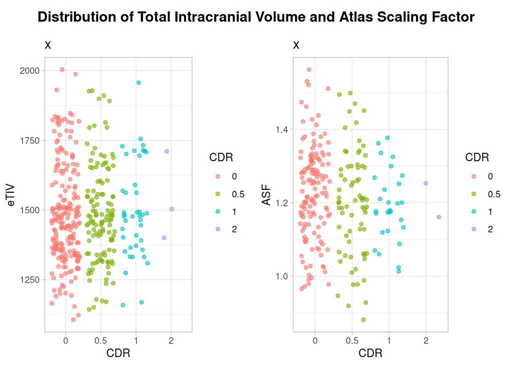

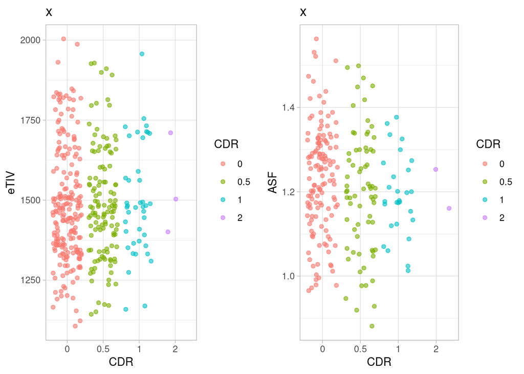

Here, we cqn see that normalized whole-brain volume seems to have a bigger spread for subjects with CDR = 0 and narrows as CDR increases.